[figure not shown]

[figure not shown]

# Indlæsning af data

```r
data <- read.table(file = "../data/Forel140225.txt", header = T)
head(data)
```

```
  M S G        y
1 1 1 4 31.76821
2 1 1 3 31.01354
3 1 1 2 28.21829
4 1 1 1 22.57111
5 2 2 2 81.97573
6 2 2 3 90.32387
```

```r
data$mark <- factor(data$M)
data$variety <- factor(data$S)
data$goedning <- factor(data$G)
head(data)
```

```
  M S G        y mark variety goedning
1 1 1 4 31.76821    1       1        4
2 1 1 3 31.01354    1       1        3
3 1 1 2 28.21829    1       1        2
4 1 1 1 22.57111    1       1        1
5 2 2 2 81.97573    2       2        2
6 2 2 3 90.32387    2       2        3
```

# Modeller baseret på undervisning i kursusuge 1-2

### Fælles niveau for alle målinger

```r
model0 <- lm(y ~ 1, data)
summary(model0)
```

```
Call:
lm(formula = y ~ 1, data = data)

Residuals:
    Min      1Q  Median      3Q     Max
-43.519 -17.575   4.972  23.522  32.425

Coefficients:
            Estimate Std. Error t value Pr(>|t|)
(Intercept)    66.09       6.63   9.969 5.21e-08 ***
---
Signif. codes:  0 '***' 0.001 '**' 0.01 '*' 0.05 '.' 0.1 ' ' 1

Residual standard error: 26.52 on 15 degrees of freedom
```

### Model med (fixed) effekt af mark

Dette er blot en 1-sidet ANOVA

```r
model1 <- lm(y ~ mark - 1, data)
summary(model1)
```

```
Call:
lm(formula = y ~ mark - 1, data = data)

Residuals:
    Min      1Q  Median      3Q     Max
-9.9140 -4.0173  0.3282  3.3186  6.6256

Coefficients:
      Estimate Std. Error t value Pr(>|t|)
mark1   28.393      2.671   10.63 1.85e-07 ***
mark2   91.890      2.671   34.40 2.32e-13 ***
mark3   86.075      2.671   32.22 5.05e-13 ***
mark4   58.002      2.671   21.71 5.33e-11 ***
---
Signif. codes:  0 '***' 0.001 '**' 0.01 '*' 0.05 '.' 0.1 ' ' 1

Residual standard error: 5.343 on 12 degrees of freedom
Multiple R-squared:  0.9957,    Adjusted R-squared:  0.9943
F-statistic: 701.4 on 4 and 12 DF,  p-value: 4.161e-14
```

```r
confint(model1)
```

```
         2.5 %   97.5 %
mark1 22.57231 34.21326
mark2 86.06922 97.71017
mark3 80.25412 91.89507
mark4 52.18191 63.82286
```

### Model med (fixed) effekter af mark og sort

Bemærk: faktoren *mark* er finere end faktoren *variety* (=sort). Derfor gør det ingen forskel om vi skriver *lm(y~mark)* eller *lm(y~variety + mark)*, da vi fittede *model1* i R ovenfor.

```r
model2<-lm(y~variety,data)
anova(model2,model1)
```

```
Analysis of Variance Table

Model 1: y ~ variety
Model 2: y ~ mark - 1
  Res.Df     RSS Df Sum of Sq      F    Pr(>F)
1     14 2163.63
2     12  342.55  2    1821.1 31.898 1.575e-05 ***
---
Signif. codes:  0 '***' 0.001 '**' 0.01 '*' 0.05 '.' 0.1 ' ' 1
```

Der er en signifikant effekt af mark. Vi kan ikke rigtig komme til at teste, om der er en effekt af *variety*. !

# Modeller med tilfældige effekter

### R pakker til fit af modeller med tilfældige effekter

Modeller med tilfældige effekter kan estimeres i R på flere måder. Vi bruger både *lme()*-funktionen fra *nlme*-pakken og *lmer()*-funktionen fra *lme4*-pakken.

Henter modeller som kan fitte modeller med tilfældige effekter

```r
library(nlme)
library(lme4)
```

### Model med tilfældig effekt af mark

```r
rmod0<-lme(y~1,random=~1|mark,data)
summary(rmod0)
```

```
Linear mixed-effects model fit by REML
 Data: data
       AIC      BIC    logLik
  115.9551 118.0792 -54.97753

Random effects:
 Formula: ~1 | mark
        (Intercept) Residual
StdDev:    29.04071 5.342793

Fixed effects: y ~ 1
               Value Std.Error DF  t-value p-value
(Intercept) 66.08987  14.58166 12 4.532396   7e-04

Standardized Within-Group Residuals:
       Min         Q1        Med         Q3        Max
-1.8150593 -0.7535976  0.0487324  0.6088226  1.2806229

Number of Observations: 16
Number of Groups: 4
```

```r
intervals(rmod0)
```

```
Approximate 95% confidence intervals

 Fixed effects:
               lower     est.    upper
(Intercept) 34.31916 66.08987 97.86057
attr(,"label")
[1] "Fixed effects:"

 Random Effects:
  Level: mark
                   lower     est.    upper
sd((Intercept)) 12.95867 29.04071 65.08099

 Within-group standard error:
   lower     est.    upper
3.581101 5.342793 7.971136
```

### Model med systematisk effekt af sort og tilfældig effekt af mark

Vigtigt: da vi ønsker at lave et såkaldt likelihood ratio test for reduktion af den systematiske del af modellen er det VIGTIGT at modellen estimeres med method=“ML”

```r
rmodel1<-lme(y~variety-1,random=~1|mark,data,method="ML")
summary(rmodel1)
```

```
Linear mixed-effects model fit by maximum likelihood
 Data: data
       AIC      BIC    logLik
  118.1076 121.1979 -55.05379

Random effects:
 Formula: ~1 | mark
        (Intercept) Residual
StdDev:    10.32868 5.342793

Fixed effects: y ~ variety - 1
            Value Std.Error DF   t-value p-value
variety1 43.19759  8.064665  2  5.356402  0.0331
variety2 88.98215  8.064665  2 11.033582  0.0081
 Correlation:
         varty1
variety2 0

Standardized Within-Group Residuals:
       Min         Q1        Med         Q3        Max
-1.8214563 -0.6301433  0.2351738  0.6330776  1.2742258

Number of Observations: 16
Number of Groups: 4
```

```r
rmodel2<-lme(y~1,random=~1|mark,data,method="ML")
summary(rmodel2)
```

```
Linear mixed-effects model fit by maximum likelihood
 Data: data
       AIC      BIC    logLik
  123.0017 125.3195 -58.50087

Random effects:
 Formula: ~1 | mark
        (Intercept) Residual
StdDev:     25.1145 5.342793

Fixed effects: y ~ 1
               Value Std.Error DF  t-value p-value
(Intercept) 66.08987  13.04223 12 5.067373   3e-04

Standardized Within-Group Residuals:
        Min          Q1         Med          Q3         Max
-1.80155316 -0.75415749  0.04449863  0.60826279  1.29412899

Number of Observations: 16
Number of Groups: 4
```

```r
anova(rmodel2,rmodel1) ### giver p-værdi på p=0.009
```

```
        Model df      AIC      BIC    logLik   Test  L.Ratio p-value
rmodel2     1  3 123.0017 125.3195 -58.50087
rmodel1     2  4 118.1076 121.1979 -55.05379 1 vs 2 6.894165  0.0086
```

```r
intervals(rmodel1)
```

```
Approximate 95% confidence intervals

 Fixed effects:
            lower     est.     upper
variety1 10.73922 43.19759  75.65595
variety2 56.52378 88.98215 121.44051
attr(,"label")
[1] "Fixed effects:"

 Random Effects:
  Level: mark
                lower     est.    upper
sd((Intercept)) 4.929 10.32868 21.64366

 Within-group standard error:
   lower     est.    upper
3.581114 5.342793 7.971107
```

Vigtigt: der er kun tale om en approksimativ p-værdi, så man kan evt simulere p-værdien for at se om man kan stole på den approksimative p-værdi. Bemærk desuden af resultatet nedenfor afhænger (lidt) af det valgte *seed* (her: seed = 1).

```r
sim<-simulate.lme(rmodel2,m2=rmodel1,seed=1,nsim=1000)
lr.sim<-2*(sim$alt$ML-sim$null$ML)
psim<-sum(lr.sim>6.894)/1000
psim
```

```
[1] 0.085
```

# Markforsøg som et split-plotforsøg

### Model for split-plot forsøg

Ved denne analyse indgår *variety*, *goedning* samt deres vekselvirkning (variety x goedning) som systematiske faktorer og *mark* indgår som tilfældig effekt.

```r
r0<-lme(y~variety*goedning,random=~1|mark,data,method="ML")
r1<-lme(y~variety+goedning,random=~1|mark,data,method="ML")
anova(r1,r0) ### ingen vekselvirkning: LR=1.802, p=0.615
```

```
   Model df      AIC      BIC    logLik   Test  L.Ratio p-value
r1     1  7 123.6168 129.0249 -54.80841
r0     2 10 127.8149 135.5408 -53.90743 1 vs 2 1.801942  0.6145
```

```r
r2<-lme(y~variety,random=~1|mark,data,method="ML")
anova(r2,r1) ### ingen effekt af goedning: LR=0.491, p=0.921
```

```
   Model df      AIC      BIC    logLik   Test   L.Ratio p-value
r2     1  4 118.1076 121.1979 -55.05379
r1     2  7 123.6168 129.0249 -54.80841 1 vs 2 0.4907676  0.9209
```

Bemærk: analysen (dvs. test for) effekten af “variety” er foretaget tidligere i R-programmet og skippes her!

### udvidet figur (kode)

Udvidet figur, hvor følgende ændres (parameternavn i parentes):

- interval for y-akse (ylim)
- skriftstørrelse på akser (cex.axis)
- skriftstørrelse af akselabels (cex.lab)
- overskrift (title)
- størrelse på overskrift (cex.main)
- størrelse på symboler (cex)
- signaturforklaring (legend)
- akser ikke med på oprindelig figur (axes=FALSE) men sættes på en af gangen med
- funktionen “axis”

```r
symbolListe<-c("A","C","K","N")
farveListe<-c("blue","red")
plot(M,y,xlab="Mark nummer",ylab="Udbytte"
,ylim=c(0,140),cex.axis=1.25,cex.lab=1.25,cex.main=1.5,cex=1.5
,pch=symbolListe[G],col=farveListe[S],axes=FALSE)
title("Resultater fra dyrkningsforsoeg")
axis(side=2,cex.axis=1.25)
axis(side=1,at=c(1,2,3,4),labels=c("Mark 1","Mark 2","Mark 3","Mark 4"),cex.axis=1.25)
legend(1,140,legend=c("Sort 1","Sort 2"),fill=c("blue","red"),bty="n",cex=1.25)
```

### udvidet figur

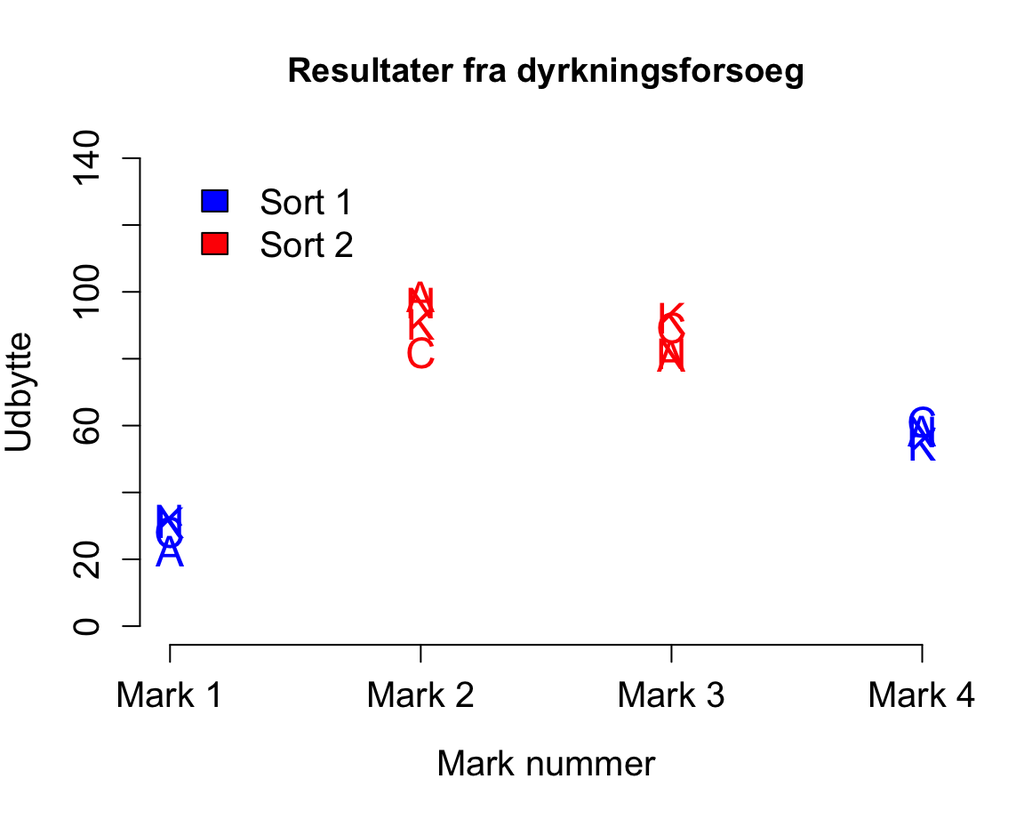

### ggplot2 (kode)

```r
library(ggplot2)
ggplot(data = data) + geom_point(mapping = aes(x = mark, y = y, color = goedning, size = variety)) +
xlab("Mark nummer") + ylab("Udbytte")
```

### ggplot (figur)

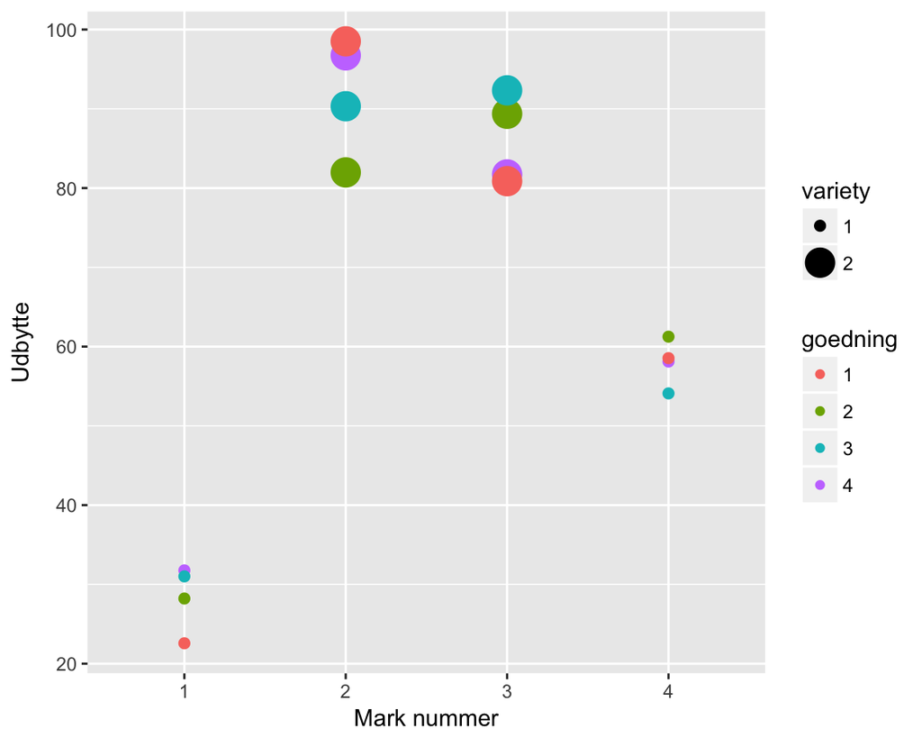

# Eksempel 8.1: Mørhed af svinekød

### Indlæsning af data

```r
tender<-read.table("../data/tenderness.txt",header=T)
head(tender)
```

```
  porker  pH  chill    y
1      1 low tunnel 7.22
2      2 low tunnel 3.11
3      3 low tunnel 7.44
4      4 low tunnel 4.33
5      5 low tunnel 6.78
6      6 low tunnel 5.56
```

```r
tender$porker<-factor(tender$porker)
```

### Test af vekselvirkning

```r
m0<-lme(y~pH*chill,random=~1|porker,tender,method="ML")
m1<-lme(y~pH+chill,random=~1|porker,tender,method="ML")
anova(m1,m0) ### ingen vekselvirkning, p=0.662
```

```
   Model df      AIC      BIC    logLik   Test   L.Ratio p-value
m1     1  5 149.9008 159.2568 -69.95041
m0     2  6 151.7097 162.9369 -69.85483 1 vs 2 0.1911661  0.6619
```

### Test af hovedeffekter

```r
m2a<-lme(y~chill,random=~1|porker,tender,method="ML")
anova(m2a,m1) ### sign effekt af pH, p=0.0048
```

```
    Model df      AIC      BIC    logLik   Test  L.Ratio p-value
m2a     1  4 155.8719 163.3567 -73.93596
m1      2  5 149.9008 159.2568 -69.95041 1 vs 2 7.971096  0.0048
```

```r
m2b<-lme(y~pH,random=~1|porker,tender,method="ML")
anova(m2b,m1) ### ingen effekt af chill, p=0.1278
```

```
    Model df      AIC      BIC    logLik   Test  L.Ratio p-value
m2b     1  4 150.2197 157.7045 -71.10983
m1      2  5 149.9008 159.2568 -69.95041 1 vs 2 2.318832  0.1278
```

```r
m3<-lme(y~1,random=~1|porker,tender,method="ML")
anova(m3,m2b)
```

```
    Model df      AIC      BIC    logLik   Test  L.Ratio p-value
m3      1  3 156.1908 161.8044 -75.09538
m2b     2  4 150.2197 157.7045 -71.10983 1 vs 2 7.971096  0.0048
```